# Alpha-synuclein

## Figure 4: Best-cluster predicted contact maps over the two true folds.

Predicted contact maps (MSA-Transformer) for the clusters best matching each fold, over the true contacts of fold 1 (upper triangle) and fold 2 (lower). Divergent contacts between clusters are the contact-level signature of fold-switching.

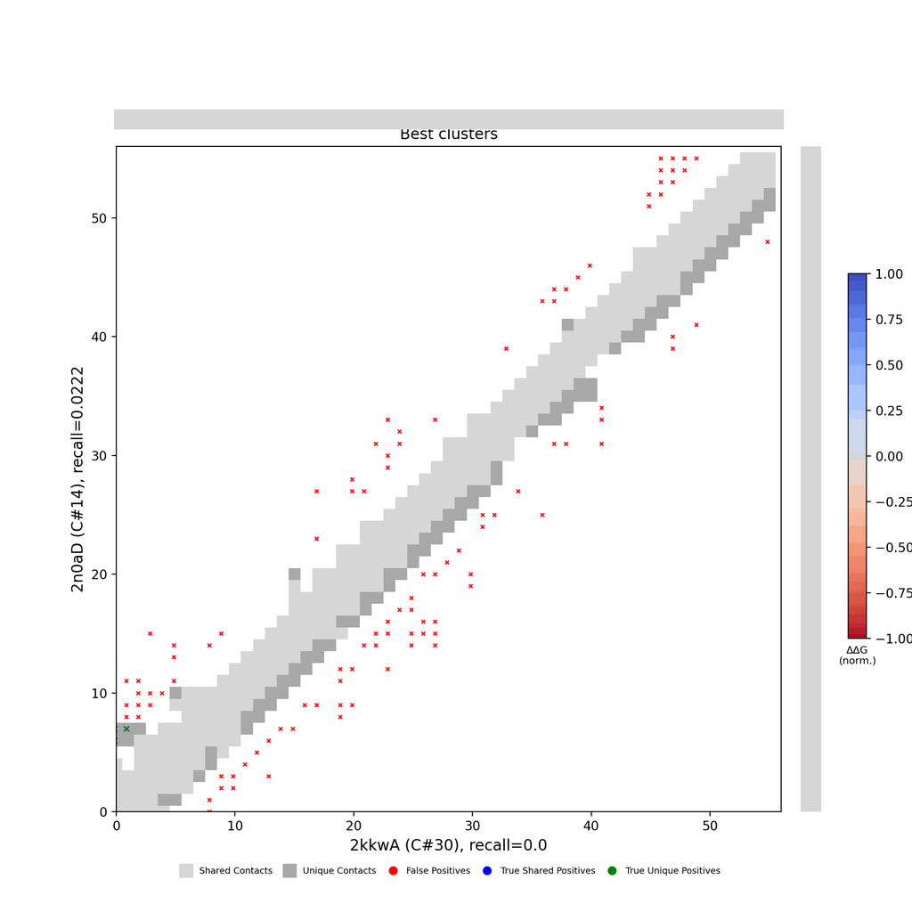

## Figure 5: Per-residue ΔΔG fold-preference contribution

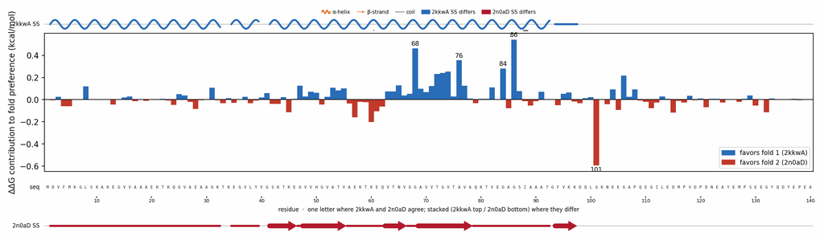

**More figures**

## Figure 6: Deep-MSA contact map panel / Best clusters contact map panel

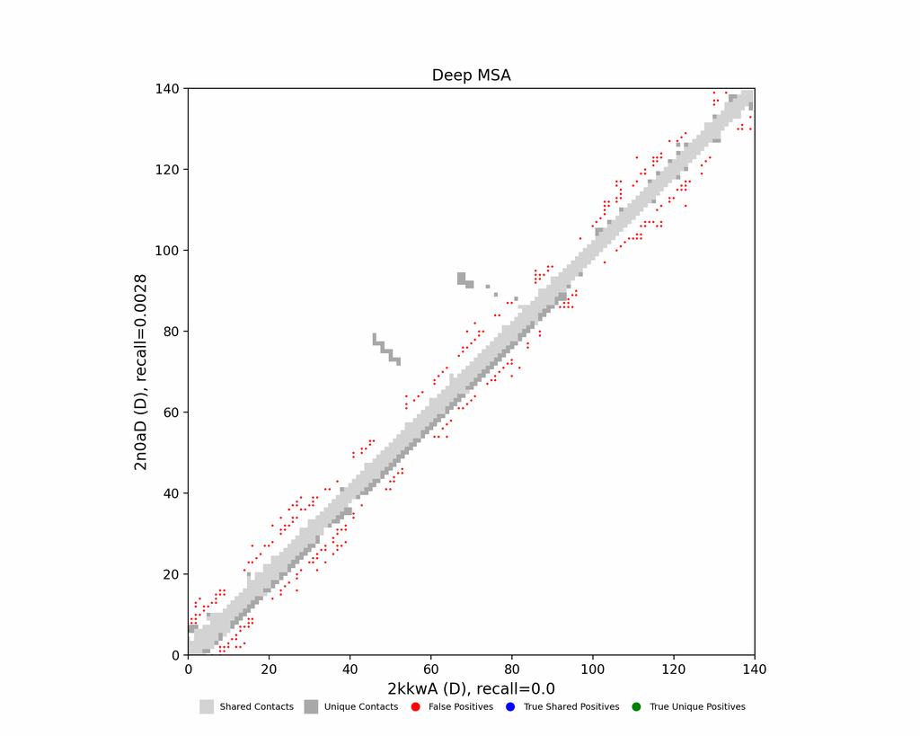

Deep-MSA contact map panel

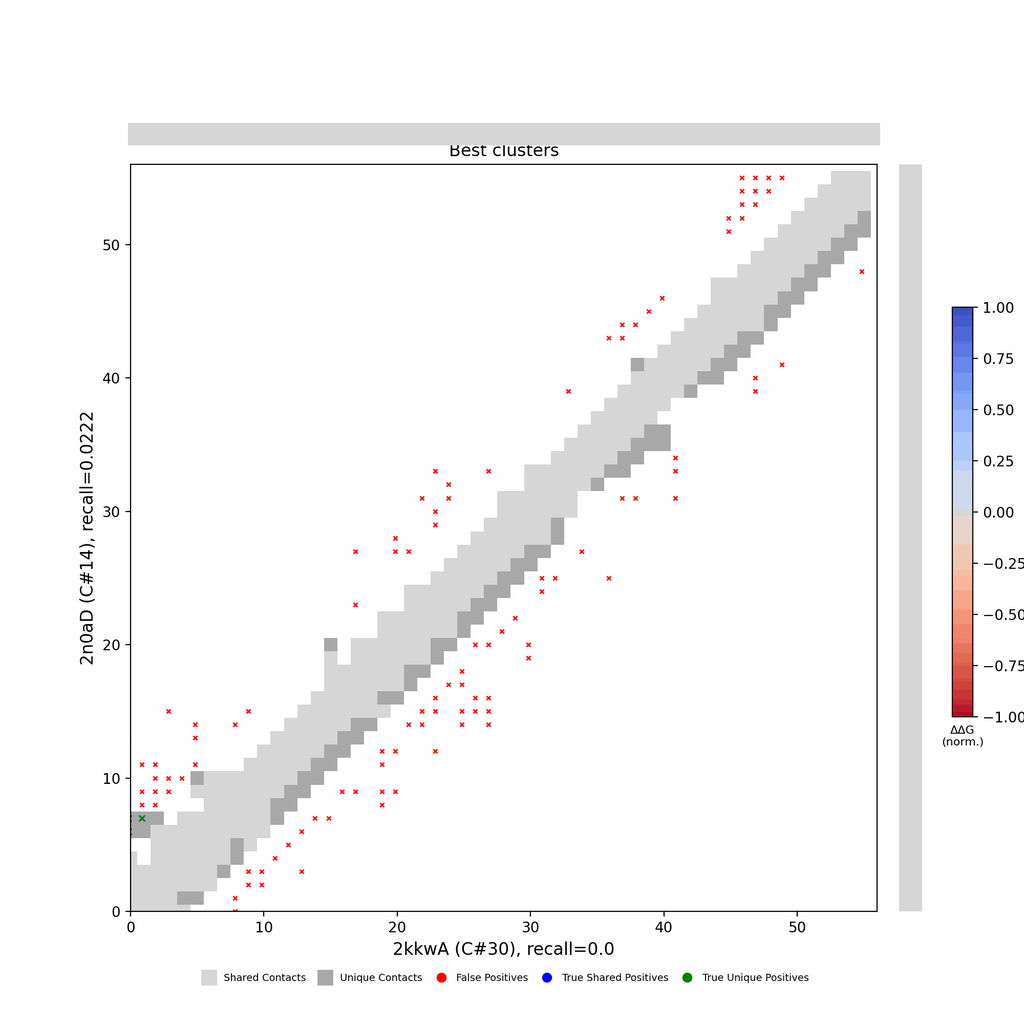

Best clusters contact map panel

## Figure 7: All clusters contact-map mosaic (small multiples).

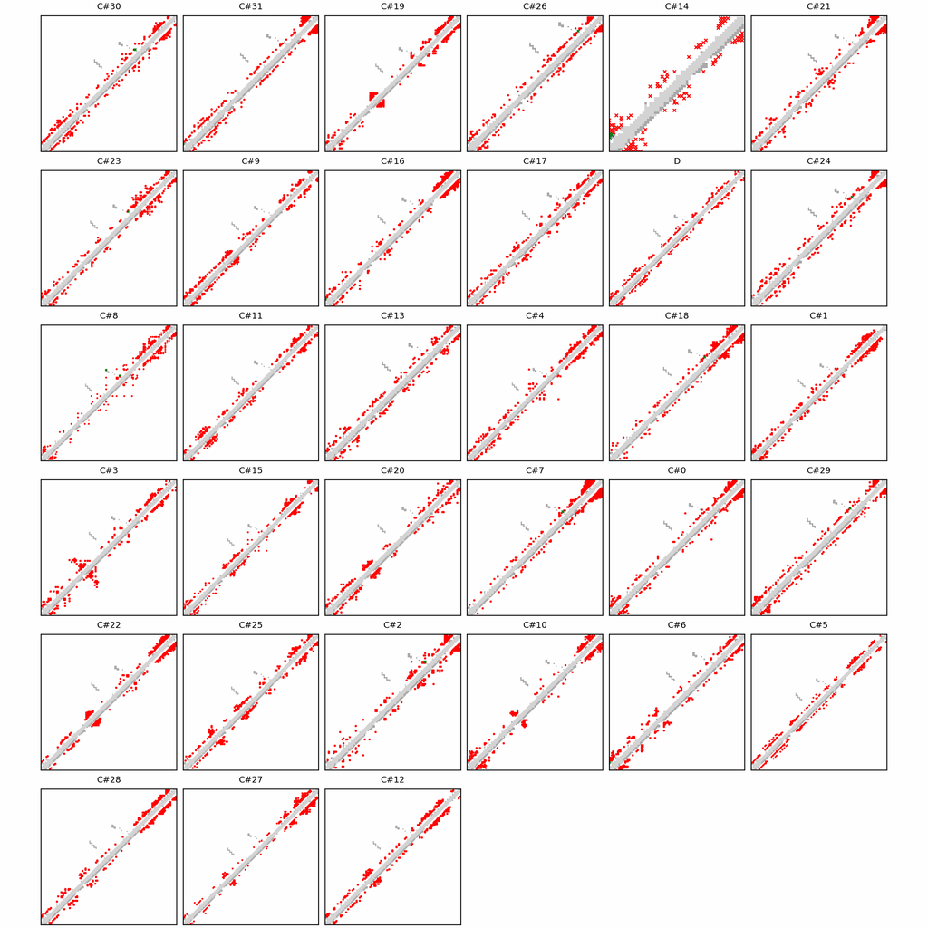

## Figure 8: Phylo null: tree with shuffled cluster fold labels.

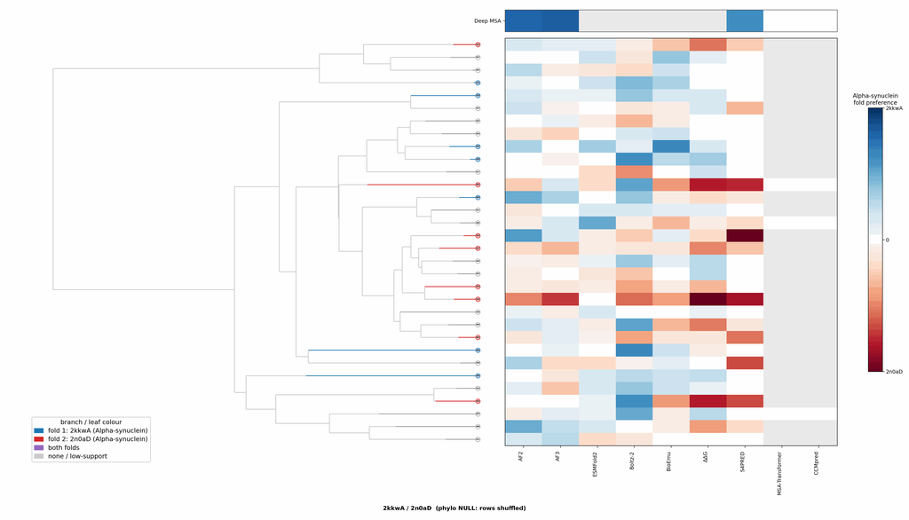

## Cluster metrics table

Per-cluster metrics underlying the figures above.

| cluster | n | neff | AF2_TM1 | AF2_TM2 | AF3_TM1 | AF3_TM2 | RE-MSAT-COM | RE-MSAT1 | RE-MSAT2 | ESM_SEQIDS | ESM_TM1 | ESM_TM2 | ΔΔG_Bias | ΔΔG_Bias_std | ΔΔG_frac_F1 | Boltz2_pref | S4PRED_pref | CCMpred_pref | BioEmu_pref |
| --- | --- | --- | --- | --- | --- | --- | --- | --- | --- | --- | --- | --- | --- | --- | --- | --- | --- | --- | --- |
| Deep | - | - | 0.37 | 0.16 | 0.32 | 0.18 | 0.0 | 0.0 | 0.0 | - | - | - | - | - | - | - | 0.38 | 0.0 | - |
| 000 | 143.0 | 14.0 | 0.28 | 0.18 | 0.32 | 0.18 | 0.0 | 0.0 | 0.0 | 009; 009; 004; 004; 001; 007; 007; 010; 003; 010 | 0.26 ± 0.02 | 0.18 ± 0.03 | 2.65 | 2.99 | 0.9 | 0.03 | 0.37 | 0.0 | -0.0 |
| 001 | 52.0 | 4.0 | 0.22 | 0.17 | 0.35 | 0.22 | 0.0 | 0.0 | 0.0 | 010; 010; 002; 004; 005; 005; 002; 004; 003; 003 | 0.30 ± 0.01 | 0.17 ± 0.02 | -1.33 | 0.9 | 0.1 | 0.11 | 0.02 | 0.0 | -0.01 |
| 002 | 52.0 | 1.0 | 0.3 | 0.2 | 0.3 | 0.17 | 0.0 | 0.0 | 0.0 | 005; 005; 002; 002; 003; 003; 001; 010; 001; 004 | 0.25 ± 0.01 | 0.16 ± 0.02 | 4.62 | 0.78 | 1.0 | 0.12 | 0.48 | 0.0 | 0.03 |
| 003 | 40.0 | 2.0 | 0.29 | 0.17 | 0.32 | 0.2 | 0.0 | 0.0 | 0.0 | - | - | - | 2.99 | 0.56 | 1.0 | 0.0 | 0.46 | - | 0.05 |
| 004 | 36.0 | 1.0 | 0.36 | 0.19 | 0.3 | 0.17 | 0.0 | 0.0 | 0.0 | - | - | - | 0.19 | 0.88 | 0.6 | 0.13 | 0.38 | - | -0.0 |
| 005 | 36.0 | 12.0 | 0.26 | 0.19 | 0.3 | 0.17 | 0.0 | 0.0 | 0.0 | - | - | - | 2.39 | 2.94 | 0.7 | 0.0 | 0.15 | - | 0.03 |
| 006 | 34.0 | 1.0 | 0.3 | 0.18 | 0.32 | 0.19 | 0.0 | 0.0 | 0.0 | - | - | - | 2.72 | 0.72 | 1.0 | 0.11 | 0.49 | - | 0.07 |
| 007 | 33.0 | 1.0 | 0.32 | 0.2 | 0.31 | 0.19 | 0.0 | 0.0 | 0.0 | - | - | - | 3.6 | 0.77 | 1.0 | 0.02 | 0.48 | - | 0.08 |
| 008 | 33.0 | 1.0 | 0.41 | 0.17 | 0.38 | 0.22 | 0.0 | 0.0 | 0.0 | - | - | - | 0.73 | 0.77 | 0.8 | 0.1 | 0.37 | - | 0.05 |
| 009 | 33.0 | 5.0 | 0.43 | 0.19 | 0.34 | 0.18 | 0.0 | 0.0 | 0.0 | - | - | - | 1.85 | 1.44 | 0.9 | 0.11 | 0.41 | - | 0.02 |
| 010 | 30.0 | 1.0 | 0.15 | 0.16 | 0.19 | 0.19 | 0.0 | 0.0 | 0.0 | - | - | - | -2.48 | 0.51 | 0.0 | -0.01 | -0.02 | - | -0.0 |
| 011 | 30.0 | 2.0 | 0.33 | 0.17 | 0.36 | 0.2 | 0.0 | 0.0 | 0.0 | - | - | - | 3.09 | 0.89 | 1.0 | 0.03 | 0.46 | - | 0.05 |
| 012 | 30.0 | 2.0 | 0.35 | 0.18 | 0.29 | 0.19 | 0.0 | 0.0 | 0.0 | - | - | - | 3.7 | 0.87 | 1.0 | 0.02 | 0.28 | - | 0.06 |
| 013 | 27.0 | 4.0 | 0.3 | 0.17 | 0.3 | 0.18 | 0.0 | 0.0 | 0.0 | - | - | - | 3.24 | 0.84 | 1.0 | 0.12 | 0.48 | - | 0.08 |
| 014 | 26.0 | 7.0 | 0.42 | 0.16 | 0.33 | 0.2 | 0.0 | 0.0 | 0.0 | - | - | - | 2.06 | 3.32 | 0.6 | 0.01 | -0.13 | - | 0.07 |
| 015 | 25.0 | 1.0 | 0.36 | 0.2 | 0.34 | 0.21 | 0.0 | 0.0 | 0.0 | - | - | - | 0.08 | 1.18 | 0.5 | 0.07 | 0.32 | - | 0.02 |
| 016 | 24.0 | 6.0 | 0.3 | 0.18 | 0.31 | 0.19 | 0.0 | 0.0 | 0.0 | - | - | - | -1.39 | 1.07 | 0.0 | 0.12 | 0.07 | - | -0.01 |
| 017 | 23.0 | 5.0 | 0.31 | 0.2 | 0.33 | 0.22 | 0.0 | 0.0 | 0.0 | - | - | - | 4.26 | 0.66 | 1.0 | -0.02 | 0.5 | - | 0.05 |
| 018 | 22.0 | 1.0 | 0.35 | 0.19 | 0.32 | 0.2 | 0.0 | 0.0 | 0.0 | - | - | - | 3.9 | 0.73 | 1.0 | 0.13 | 0.49 | - | 0.06 |
| 019 | 22.0 | 1.0 | 0.31 | 0.18 | 0.3 | 0.2 | 0.0 | 0.0 | 0.0 | - | - | - | 3.43 | 0.96 | 1.0 | 0.01 | 0.48 | - | 0.05 |
| 020 | 22.0 | 10.0 | 0.26 | 0.18 | 0.3 | 0.22 | 0.0 | 0.0 | 0.0 | - | - | - | 2.99 | 1.31 | 1.0 | 0.06 | 0.5 | - | 0.08 |
| 021 | 21.0 | 2.0 | 0.3 | 0.21 | 0.29 | 0.18 | 0.0 | 0.0 | 0.0 | - | - | - | 3.58 | 1.0 | 1.0 | 0.06 | 0.48 | - | 0.06 |
| 022 | 21.0 | 7.0 | 0.35 | 0.15 | 0.31 | 0.2 | 0.0 | 0.0 | 0.0 | - | - | - | 4.04 | 1.51 | 1.0 | 0.05 | 0.48 | - | 0.11 |
| 023 | 21.0 | 4.0 | 0.27 | 0.17 | 0.32 | 0.22 | 0.0 | 0.0 | 0.0 | - | - | - | 1.23 | 1.04 | 0.8 | -0.01 | 0.49 | - | 0.05 |
| 024 | 20.0 | 1.0 | 0.31 | 0.17 | 0.31 | 0.25 | 0.0 | 0.0 | 0.0 | - | - | - | 3.41 | 0.73 | 1.0 | 0.11 | 0.48 | - | 0.08 |
| 025 | 20.0 | 3.0 | 0.29 | 0.19 | 0.32 | 0.21 | 0.0 | 0.0 | 0.0 | - | - | - | 4.49 | 1.78 | 0.9 | 0.01 | 0.5 | - | 0.04 |
| 026 | 15.0 | 1.0 | 0.31 | 0.2 | 0.3 | 0.21 | 0.0 | 0.0 | 0.0 | - | - | - | 4.4 | 0.86 | 1.0 | 0.07 | 0.48 | - | 0.07 |
| 027 | 15.0 | 5.0 | 0.28 | 0.21 | 0.31 | 0.25 | 0.0 | 0.0 | 0.0 | - | - | - | 0.27 | 0.65 | 0.6 | 0.06 | 0.31 | - | 0.05 |
| 028 | 15.0 | 1.0 | 0.38 | 0.18 | 0.3 | 0.22 | 0.0 | 0.0 | 0.0 | - | - | - | 2.98 | 0.46 | 1.0 | 0.06 | 0.09 | - | 0.06 |
| 029 | 14.0 | 1.0 | 0.32 | 0.21 | 0.3 | 0.2 | 0.0 | 0.0 | 0.0 | - | - | - | 4.45 | 0.6 | 1.0 | 0.1 | 0.49 | - | 0.06 |
| 030 | 14.0 | 4.0 | 0.3 | 0.19 | 0.3 | 0.2 | 0.0 | 0.0 | 0.0 | - | - | - | 4.95 | 0.48 | 1.0 | 0.1 | 0.48 | - | 0.07 |
| 031 | 13.0 | 1.0 | 0.4 | 0.22 | 0.32 | 0.22 | 0.0 | 0.0 | 0.0 | - | - | - | 3.1 | 0.68 | 1.0 | 0.01 | 0.49 | - | 0.08 |